# Import and Tibbles

```r
library(tidyverse)
```

### Chapter 8 - Data Import with readr

#### Getting Started

##### Examples

##### Exercises

1. What function would you use to read a file where fields are separated with “|”?
2. Apart from file, skip, and comment, what other arguments do `read_csv()` and `read_tsv()` have in common?
3. What are the most important arguments to `read_fwf()`?
4. Sometimes strings in a CSV file contain commas. To prevent them from causing problems they need to be surrounded by a quoting character, like " or ‘. By convention, read_csv() assumes that the quoting character will be “, and if you want to change it you’ll need to use `read_delim()` instead. What arguments do you need to specify to read the following text into a data frame?”x,y1,’a,b’"
5. Identify what is wrong with each of the following inline CSV files. What happens when you run the code? `read_csv("a,b\n1,2,3\n4,5,6")` `read_csv("a,b,c\n1,2\n1,2,3,4")` `read_csv("a,b\n\"1")` `read_csv("a,b\n1,2\na,b")` `read_csv("a;b\n1;3")`

#### Parsing a vector

##### Examples

##### Exercises

1. What are the most important arguments to `locale()`?
2. What happens if you try and set `decimal_mark` and `grouping_mark` to the same character? What happens to the default value of `grouping_mark` when you set `decimal_mark` to “,“? What happens to the default value of `decimal_mark` when you set the grouping_mark to”.“?
3. I didn’t discuss the `date_format` and `time_format` options to `locale()`. What do they do? Construct an example that shows when they might be useful.
4. If you live outside the US, create a new locale object that encapsulates the settings for the types of files you read most commonly.
5. What’s the difference between `read_csv()` and `read_csv2()`?
6. What are the most common encodings used in Europe? What are the most common encodings used in Asia? Do some goo‐ gling to find out.
7. Generate the correct format string to parse each of the following dates and times: d1 <- “January 1, 2010” d2 <- “2015-Mar-07” d3 <- “06-Jun-2017” d4 <- c(“August 19 (2015)”, “July 1 (2015)”) d5 <- “12/30/14” # Dec 30, 2014 t1 <- “1705” t2 <- “11:15:10.12 PM”

#### Writing to a File

##### Examples

##### Exercises

#### Other Types of data

##### Examples

##### Exercises

### Chapter 7 - Tibbles with tibble …

##### Examples

##### Exercises

#### Creating tibbles

##### Examples

##### Exercises

#### Tibbles Versus data.frame

##### Examples

##### Exercises

#### Interacting with Older Code

##### Examples

##### Exercises

1. How can you tell if an object is a tibble? (Hint: try printing mtcars, which is a regular data frame.)
2. Compare and contrast the following operations on a data.frame and equivalent tibble. What is different? Why might the default data frame behaviors cause you frustration? `df <- data.frame(abc = 1, xyz = "a")` `df$x` `df[, "xyz"]` `df[, c("abc", "xyz")]`
3. If you have the name of a variable stored in an object, e.g., var <- “mpg”, how can you extract the reference variable from a tib‐ ble?
4. Practice referring to nonsyntactic names in the following data frame by:
1. Extracting the variable called 1.
2. Plotting a scatterplot of 1 versus 2.
3. Creating a new column called 3, which is 2 divided by 1.
4. Renaming the columns to one, two, and three: annoying <- tibble( `1` = 1:10, `2` = `1` * 2 + rnorm(length(`1`)) )
5. What does tibble::enframe() do? When might you use it?
6. What option controls how many additional column names are printed at the footer of a tibble?

## Solutions

### Getting Started

1. What function would you use to read a file where fields are separated with “|”?

```r
read_delim(file, delim = "|")
```

2. Apart from file, skip, and comment, what other arguments do read_csv() and read_tsv() have in common?

```r
union(names(formals(read_csv)), names(formals(read_tsv)))
```

```
##  [1] "file"      "col_names" "col_types" "locale"    "na"
##  [6] "quoted_na" "quote"     "comment"   "trim_ws"   "skip"
## [11] "n_max"     "guess_max" "progress"
```

- `col_names` and `col_types` are used to specify the column names and how to parse the columns
- `locale` is important for determining things like the encoding and whether “.” or “,” is used as a decimal mark.
- `na` and quoted_na control which strings are treated as missing values when parsing vectors
- `trim_ws` trims whitespace before and after cells before parsing
- `n_max` sets how many rows to read
- `guess_max` sets how many rows to use when guessing the column type
- `progress` determines whether a progress bar is shown.
3. What are the most important arguments to read_fwf()?

The most important argument to `read_fwf` which reads “fixed-width formats”, is col_positions which tells the function where data columns begin and end.

4. Sometimes strings in a CSV file contain commas. To prevent them from causing problems they need to be surrounded by a quoting character, like " or ‘. By convention, read_csv() assumes that the quoting character will be “, and if you want to change it you’ll need to use read_delim() instead. What arguments do you need to specify to read the following text into a data frame?”x,y1,’a,b’"

```r
x <- "x,y\n1,'a,b'"
read_delim(x, ",", quote = "'")
```

```
## # A tibble: 1 x 2
##       x     y
##   <int> <chr>
## 1     1   a,b
```

5. Identify what is wrong with each of the following inline CSV files. What happens when you run the code? `read_csv("a,b\n1,2,3\n4,5,6")` `read_csv("a,b,c\n1,2\n1,2,3,4")` `read_csv("a,b\n\"1")` `read_csv("a,b\n1,2\na,b")` `read_csv("a;b\n1;3")`

```r
read_csv("a,b\n1,2,3\n4,5,6")
```

```
## # A tibble: 2 x 2
##       a     b
##   <int> <int>
## 1     1     2
## 2     4     5
```

Only 2 columns specified in header so last column is missed.

```r
read_csv("a,b,c\n1,2\n1,2,3,4")
```

```
## # A tibble: 2 x 3
##       a     b     c
##   <int> <int> <int>
## 1     1     2    NA
## 2     1     2     3
```

Missing value for row 1, column 3 and too many values for row 2 so last value is dropped.

```r
read_csv("a,b\n\"1")
```

```
## # A tibble: 1 x 2
##       a     b
##   <int> <chr>
## 1     1  <NA>
```

Opening quote before the 1 is removed.

```r
read_csv("a,b\n1,2\na,b")
```

```
## # A tibble: 2 x 2
##       a     b
##   <chr> <chr>
## 1     1     2
## 2     a     b
```

a and b are treated as characters.

```r
read_csv("a;b\n1;3")
```

```
## # A tibble: 1 x 1
##   `a;b`
##   <chr>
## 1   1;3
```

The values are separated by “;” rather than “,”. Use `read_csv2` instead:

```r
read_csv2("a;b\n1;3")
```

```
## # A tibble: 1 x 2
##       a     b
##   <int> <int>
## 1     1     3
```

### Parsing a vector

1. What are the most important arguments to `locale()`?
- date and time formats: `date_names`, `date_format`, and `time_format`
- time_zone: `tz`
- numbers: `decimal_mark`, `grouping_mark`
- encoding: `encoding`
2. What happens if you try and set `decimal_mark` and `grouping_mark` to the same character?

Throws are error:

```r
locale(decimal_mark = ".", grouping_mark = ".")
#Error: `decimal_mark` and `grouping_mark` must be different
```

What happens to the default value of `grouping_mark` when you set `decimal_mark` to “,“?

If the `decimal_mark` is set to the comma “,”, then the grouping mark is set to the period “.”.

What happens to the default value of `decimal_mark` when you set the grouping_mark to “.“?

If the grouping mark is set to a period, then the decimal mark is set to a comma.

3. I didn’t discuss the `date_format` and `time_format` options to `locale()`. What do they do? Construct an example that shows when they might be useful.

They provide default date and time formats.

4. If you live outside the US, create a new locale object that encapsulates the settings for the types of files you read most commonly.
5. What’s the difference between `read_csv()` and `read_csv2()`?

The delimiter. The function read_csv uses a comma, while read_csv2 uses a semi-colon (;). Using a semi-colon is useful when commas are used as the decimal point (as in Europe).

6. What are the most common encodings used in Europe? What are the most common encodings used in Asia? Do some goo‐ gling to find out.

UTF-8 is standard now, and ASCII has been around forever.

7. Generate the correct format string to parse each of the following dates and times:

```r
d1 <- "January 1, 2010"
d2 <- "2015-Mar-07"
d3 <- "06-Jun-2017"
d4 <- c("August 19 (2015)", "July 1 (2015)")
d5 <- "12/30/14" # Dec 30, 2014
t1 <- "1705"
t2 <- "11:15:10.12 PM"


parse_date(d1, "%B %d, %Y")
```

```
## [1] "2010-01-01"
```

```
#> [1] "2010-01-01"
```

```r
parse_date(d2, "%Y-%b-%d")
```

```
## [1] "2015-03-07"
```

```
#> [1] "2015-03-07"
```

```r
parse_date(d3, "%d-%b-%Y")
```

```
## [1] "2017-06-06"
```

```
#> [1] "2017-06-06"
```

```r
parse_date(d4, "%B %d (%Y)")
```

```
## [1] "2015-08-19" "2015-07-01"
```

```
#> [1] "2015-08-19" "2015-07-01"
```

```r
parse_date(d5, "%m/%d/%y")
```

```
## [1] "2014-12-30"
```

```
#> [1] "2014-12-30"
```

```r
parse_time(t1, "%H%M")
```

```
## 17:05:00
```

```
#> 17:05:00
```

### Tibbles

1. How can you tell if an object is a tibble? (Hint: try printing mtcars, which is a regular data frame.)

```r
mtcars
```

```
##                      mpg cyl  disp  hp drat    wt  qsec vs am gear carb
## Mazda RX4           21.0   6 160.0 110 3.90 2.620 16.46  0  1    4    4
## Mazda RX4 Wag       21.0   6 160.0 110 3.90 2.875 17.02  0  1    4    4
## Datsun 710          22.8   4 108.0  93 3.85 2.320 18.61  1  1    4    1
## Hornet 4 Drive      21.4   6 258.0 110 3.08 3.215 19.44  1  0    3    1
## Hornet Sportabout   18.7   8 360.0 175 3.15 3.440 17.02  0  0    3    2
## Valiant             18.1   6 225.0 105 2.76 3.460 20.22  1  0    3    1
## Duster 360          14.3   8 360.0 245 3.21 3.570 15.84  0  0    3    4
## Merc 240D           24.4   4 146.7  62 3.69 3.190 20.00  1  0    4    2
## Merc 230            22.8   4 140.8  95 3.92 3.150 22.90  1  0    4    2
## Merc 280            19.2   6 167.6 123 3.92 3.440 18.30  1  0    4    4
## Merc 280C           17.8   6 167.6 123 3.92 3.440 18.90  1  0    4    4
## Merc 450SE          16.4   8 275.8 180 3.07 4.070 17.40  0  0    3    3
## Merc 450SL          17.3   8 275.8 180 3.07 3.730 17.60  0  0    3    3
## Merc 450SLC         15.2   8 275.8 180 3.07 3.780 18.00  0  0    3    3
## Cadillac Fleetwood  10.4   8 472.0 205 2.93 5.250 17.98  0  0    3    4
## Lincoln Continental 10.4   8 460.0 215 3.00 5.424 17.82  0  0    3    4
## Chrysler Imperial   14.7   8 440.0 230 3.23 5.345 17.42  0  0    3    4
## Fiat 128            32.4   4  78.7  66 4.08 2.200 19.47  1  1    4    1
## Honda Civic         30.4   4  75.7  52 4.93 1.615 18.52  1  1    4    2
## Toyota Corolla      33.9   4  71.1  65 4.22 1.835 19.90  1  1    4    1
## Toyota Corona       21.5   4 120.1  97 3.70 2.465 20.01  1  0    3    1
## Dodge Challenger    15.5   8 318.0 150 2.76 3.520 16.87  0  0    3    2
## AMC Javelin         15.2   8 304.0 150 3.15 3.435 17.30  0  0    3    2
## Camaro Z28          13.3   8 350.0 245 3.73 3.840 15.41  0  0    3    4
## Pontiac Firebird    19.2   8 400.0 175 3.08 3.845 17.05  0  0    3    2
## Fiat X1-9           27.3   4  79.0  66 4.08 1.935 18.90  1  1    4    1
## Porsche 914-2       26.0   4 120.3  91 4.43 2.140 16.70  0  1    5    2
## Lotus Europa        30.4   4  95.1 113 3.77 1.513 16.90  1  1    5    2
## Ford Pantera L      15.8   8 351.0 264 4.22 3.170 14.50  0  1    5    4
## Ferrari Dino        19.7   6 145.0 175 3.62 2.770 15.50  0  1    5    6
## Maserati Bora       15.0   8 301.0 335 3.54 3.570 14.60  0  1    5    8
## Volvo 142E          21.4   4 121.0 109 4.11 2.780 18.60  1  1    4    2
```

```r
class(mtcars)
```

```
## [1] "data.frame"
```

```r
class(as_tibble(mtcars))
```

```
## [1] "tbl_df"     "tbl"        "data.frame"
```

2. Compare and contrast the following operations on a data.frame and equivalent tibble. What is different? Why might the default data frame behaviors cause you frustration? `df <- data.frame(abc = 1, xyz = "a")` `df$x` `df[, "xyz"]` `df[, c("abc", "xyz")]`

```r
df <- data.frame(abc = 1, xyz = "a")
df$x
```

```
## [1] a
## Levels: a
```

```r
df[, "xyz"]
```

```
## [1] a
## Levels: a
```

```r
df[, c("abc", "xyz")]
```

```
##   abc xyz
## 1   1   a
```

```r
tbl <- as_tibble(df)
tbl$x
```

[output not shown]

```r
tbl[, "xyz"]
```

```
## # A tibble: 1 x 1
##      xyz
##   <fctr>
## 1      a
```

```r
tbl[, c("abc", "xyz")]
```

```
## # A tibble: 1 x 2
##     abc    xyz
##   <dbl> <fctr>
## 1     1      a
```

3. If you have the name of a variable stored in an object, e.g., `var <- "mpg"`, how can you extract the reference variable from a tibble? You can use the double bracket, like `df[[var]]`. You cannot use the dollar sign, because `df$var` would look for a column named `var`
4. Practice referring to nonsyntactic names in the following data frame by:
1. Extracting the variable called 1.
2. Plotting a scatterplot of 1 versus 2.
3. Creating a new column called 3, which is 2 divided by 1.
4. Renaming the columns to one, two, and three:

```r
          annoying <- tibble(
            `1` = 1:10,
            `2` = `1` * 2 + rnorm(length(`1`))
)
```

```r
annoying[["1"]]
```

```
##  [1]  1  2  3  4  5  6  7  8  9 10
```

```r
annoying$`1`
```

```
##  [1]  1  2  3  4  5  6  7  8  9 10
```

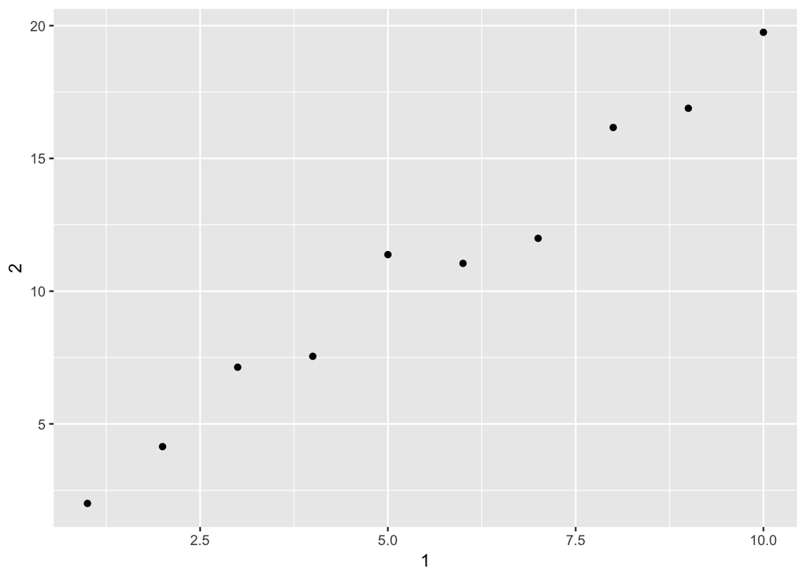

```r
ggplot(annoying, aes(x = `1`, y = `2`)) +
  geom_point()
```

```r
annoying[["3"]] <- annoying$`2` / annoying$`1`
annoying[["3"]] <- annoying[["2"]] / annoying[["1"]]
```

```r
annoying <- rename(annoying, one = `1`, two = `2`, three = `3`)
glimpse(annoying)
```

```
## Observations: 10
## Variables: 3
## $ one   <int> 1, 2, 3, 4, 5, 6, 7, 8, 9, 10
## $ two   <dbl> 2.004860, 4.144760, 7.134484, 7.545795, 11.377047, 11.04...
## $ three <dbl> 2.004860, 2.072380, 2.378161, 1.886449, 2.275409, 1.8411...
```

5. What does tibble::enframe() do? When might you use it?

```r
?tibble::enframe
```

6. What option controls how many additional column names are printed at the footer of a tibble?

```r
?print.tbl_df
```